# Project: Investigate a TMDb(The Movie Database) Movie data

- Introduction
- Data Wrangling
- Exploratory Data Analysis
- Conclusions

## Introduction

> This dataset originally came from the [kaggle challenge](https://www.kaggle.com/tmdb/tmdb-movie-metadata). The purpose of this challenge was to predict which movie will be successful before it is released. So dataset includes various features related to movie industry. We are not going to make predicting model here but checking which feature contribute for success will be an interesting and valuable question. Mainly, we are going to focus on the dataset itself and try to find out some insights from that dataset. The process will be start from checking the dataset itself to data wrangling, exploring, and visualizing. Pandas will be used for data wrangling and matplotlib will be used for viusalizing. Finally, we will show our findings and wrap it up.

```python
# import useful packages
import pandas as pd
import numpy as np
import matplotlib.pyplot as plt
import seaborn as sns
from itertools import chain

# Remember to include a 'magic word' so that your visualizations are plotted
# inline with the notebook. See this page for more:
# http://ipython.readthedocs.io/en/stable/interactive/magics.html
% matplotlib inline
```

```python
# import dataset
df = pd.read_csv('tmdb-movies.csv')
```

Cleaned dataset ✅

```python
# import dataset v1
df = pd.read_csv('tmdb_v1.csv')
```

## Data Wrangling

> **Tip**: In this section of the report, you will load in the data, check for cleanliness, and then trim and clean your dataset for analysis. Make sure that you document your steps carefully and justify your cleaning decisions.

### General Properties

First step is to understand the dataset itself. Here is some example of what can we look at.

1. what kind of properties it has?
2. row number
3. column number
4. Data type

we can check the raw data by using `head` function. You can see what kind of value is inside for each column

**Properties**

I wanted to check the detail information about each properties but cannot find detailed documents

1. `id` - ID
2. `imdb_id` - ID
3. `popularity` - How popular is the movie is
4. `budget` - how much money spent to make the movie in dollar(\$)
5. `revenue` - how much money the movie earned by dollar(\$)
6. `original title` - movie title
7. `cast` - which actor was casted?
8. `homepage` - the movies main hompage
9. `director` - who directed the movie?
10. `tagline` - representative phrase
11. `keywords` - some words that could be keywords of the movie
12. `overview` - short summary of the movie
13. `runtime` - how long the movie runs?
14. `genres` - movie genre
15. `production companies` - which company made the movie?
16. `release date` - MM/DD/YY format. what date does the movie had released?
17. `vote count` - how many people voted on this movie for assessment
18. `vote average` - what is average score of movie as a result of voting?
19. `release year` - YYYY format. what year does the movie has released?
20. `budget_adj` - calcuated the budget as of 2010 dollar value. By inflation the dollar value goes lower.
21. `revenue_adj` - calcuated the revenue as of 2010 dollar value.

The dataset is mostly consisted with text and seems the `cast, genres and production_companies` has combined texts that is seperated by `|`. The numeric data seems less. If we are going to only use numeric data it will not be hard but if we are going to analysis combined text like `cast` it will going to be more advanced.

```python
df.head(3)
```

|  | id | imdb_id | popularity | budget | revenue | original_title | cast | homepage | director | tagline | ... | overview | runtime | genres | production_companies | release_date | vote_count | vote_average | release_year | budget_adj | revenue_adj |
| --- | --- | --- | --- | --- | --- | --- | --- | --- | --- | --- | --- | --- | --- | --- | --- | --- | --- | --- | --- | --- | --- |
| 0 | 135397 | tt0369610 | 32.985763 | 150000000 | 1513528810 | Jurassic World | Chris Pratt\|Bryce Dallas Howard\|Irrfan Khan\|Vi... | http://www.jurassicworld.com/ | Colin Trevorrow | The park is open. | ... | Twenty-two years after the events of Jurassic ... | 124 | Action\|Adventure\|Science Fiction\|Thriller | Universal Studios\|Amblin Entertainment\|Legenda... | 6/9/15 | 5562 | 6.5 | 2015 | 1.379999e+08 | 1.392446e+09 |
| 1 | 76341 | tt1392190 | 28.419936 | 150000000 | 378436354 | Mad Max: Fury Road | Tom Hardy\|Charlize Theron\|Hugh Keays-Byrne\|Nic... | http://www.madmaxmovie.com/ | George Miller | What a Lovely Day. | ... | An apocalyptic story set in the furthest reach... | 120 | Action\|Adventure\|Science Fiction\|Thriller | Village Roadshow Pictures\|Kennedy Miller Produ... | 5/13/15 | 6185 | 7.1 | 2015 | 1.379999e+08 | 3.481613e+08 |
| 2 | 262500 | tt2908446 | 13.112507 | 110000000 | 295238201 | Insurgent | Shailene Woodley\|Theo James\|Kate Winslet\|Ansel... | http://www.thedivergentseries.movie/#insurgent | Robert Schwentke | One Choice Can Destroy You | ... | Beatrice Prior must confront her inner demons ... | 119 | Adventure\|Science Fiction\|Thriller | Summit Entertainment\|Mandeville Films\|Red Wago... | 3/18/15 | 2480 | 6.3 | 2015 | 1.012000e+08 | 2.716190e+08 |

3 rows × 21 columns

We can use `info()` to check the row and column number and also data type.

As we can see at the following

1. 21 columns
2. 10866 row
3. int64, float64, object datatype

The dataset itself is not perfect. There is missing data and some data's like homepage url doesn't seems necessary. In case of homepage we can use it for additional data source. But here it will be too overcomplicated things.

```python
df.shape
```

```
(10866, 21)
```

```python
df.info()
```

```
<class 'pandas.core.frame.DataFrame'>
RangeIndex: 10866 entries, 0 to 10865
Data columns (total 21 columns):
id                      10866 non-null int64
imdb_id                 10856 non-null object
popularity              10866 non-null float64
budget                  10866 non-null int64
revenue                 10866 non-null int64
original_title          10866 non-null object
cast                    10790 non-null object
homepage                2936 non-null object
director                10822 non-null object
tagline                 8042 non-null object
keywords                9373 non-null object
overview                10862 non-null object
runtime                 10866 non-null int64
genres                  10843 non-null object
production_companies    9836 non-null object
release_date            10866 non-null object
vote_count              10866 non-null int64
vote_average            10866 non-null float64
release_year            10866 non-null int64
budget_adj              10866 non-null float64
revenue_adj             10866 non-null float64
dtypes: float64(4), int64(6), object(11)
memory usage: 1.7+ MB
```

Let's check some numeric data's statistics by using `describe`.

- **release year** - From 1960 to 2015 and half of the movies are after 2006
- **runtime** - From 0 to 900. Seems 900 runtime is an outlier and even with outlier the mean value is 102 so seems around 2 hour will be normal runtime
- **budget** - we can see that more than half of the movie doesn't spend any budget and even with it the mean value is pretty close to the 75% value. It means huge money have been spent after 75% quartile.
- **revenue** - This is the good indicator of how popular the movie was. It has no revenue till 50% quartile but boost up after it. It is similar to `budget`.

```python
df.describe()
```

|  | id | popularity | budget | revenue | runtime | vote_count | vote_average | release_year | budget_adj | revenue_adj |
| --- | --- | --- | --- | --- | --- | --- | --- | --- | --- | --- |
| count | 10866.000000 | 10866.000000 | 1.086600e+04 | 1.086600e+04 | 10866.000000 | 10866.000000 | 10866.000000 | 10866.000000 | 1.086600e+04 | 1.086600e+04 |
| mean | 66064.177434 | 0.646441 | 1.462570e+07 | 3.982332e+07 | 102.070863 | 217.389748 | 5.974922 | 2001.322658 | 1.755104e+07 | 5.136436e+07 |
| std | 92130.136561 | 1.000185 | 3.091321e+07 | 1.170035e+08 | 31.381405 | 575.619058 | 0.935142 | 12.812941 | 3.430616e+07 | 1.446325e+08 |
| min | 5.000000 | 0.000065 | 0.000000e+00 | 0.000000e+00 | 0.000000 | 10.000000 | 1.500000 | 1960.000000 | 0.000000e+00 | 0.000000e+00 |
| 25% | 10596.250000 | 0.207583 | 0.000000e+00 | 0.000000e+00 | 90.000000 | 17.000000 | 5.400000 | 1995.000000 | 0.000000e+00 | 0.000000e+00 |
| 50% | 20669.000000 | 0.383856 | 0.000000e+00 | 0.000000e+00 | 99.000000 | 38.000000 | 6.000000 | 2006.000000 | 0.000000e+00 | 0.000000e+00 |
| 75% | 75610.000000 | 0.713817 | 1.500000e+07 | 2.400000e+07 | 111.000000 | 145.750000 | 6.600000 | 2011.000000 | 2.085325e+07 | 3.369710e+07 |
| max | 417859.000000 | 32.985763 | 4.250000e+08 | 2.781506e+09 | 900.000000 | 9767.000000 | 9.200000 | 2015.000000 | 4.250000e+08 | 2.827124e+09 |

Let's check the the properties with `hist`

we can see except `release year` and `vote average` other graphs are skewed to right

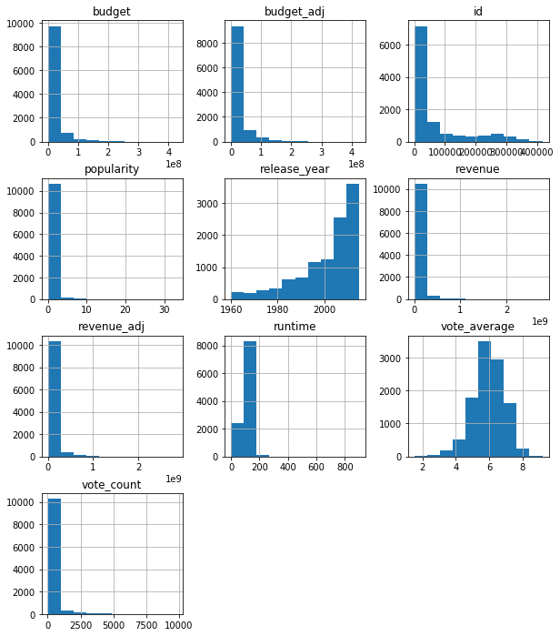

```python
df.hist(figsize=(10, 12));
```

### Data Cleaning

1. Drop unnecessary columns
2. Drop N/A rows or fill it
3. Remove duplicated rows
4. Rename columns
5. Fixing data types

> We are not going to fix the columns that has `|` as a delimiter. Rather just process directly at the analysis process

**1. Drop unnecessary columns**

We checked the dataset and now we have to clean it. First we are going to drop off the column that doesn't seems necessary. Deleted columns that is duplicated or text that need to be preprocess quite much so cannot use directly as it is. Also columns that doesn't seems to be used for analysis like `id`.

```python
# delete unnecessary column
del_columns = ['id', 'imdb_id', 'homepage', 'tagline', 'overview', 'budget_adj', 'revenue_adj']
df.drop(del_columns, axis=1, inplace=True)
```

```python
df.head(1)
```

|  | popularity | budget | revenue | original_title | cast | director | keywords | runtime | genres | production_companies | release_date | vote_count | vote_average | release_year |
| --- | --- | --- | --- | --- | --- | --- | --- | --- | --- | --- | --- | --- | --- | --- |
| 0 | 32.985763 | 150000000 | 1513528810 | Jurassic World | Chris Pratt\|Bryce Dallas Howard\|Irrfan Khan\|Vi... | Colin Trevorrow | monster\|dna\|tyrannosaurus rex\|velociraptor\|island | 124 | Action\|Adventure\|Science Fiction\|Thriller | Universal Studios\|Amblin Entertainment\|Legenda... | 6/9/15 | 5562 | 6.5 | 2015 |

**2. Drop N/A rows or fill it**

Now let's check the N/A values inside the dataset

`cast`, `directors`, `keywords`, `production companies`, `genres` won't be able to fill the N/A value because they are not numeric and we are not going to spend time searching google to fill the information. Except those all numeric columns are all fine. So we are going to simply use `dropna` to drop the rows that has the N/A values of those. If there are numeric column that seems to be able to filled then we could consider `fillna`.

```python
# Check which column has N/A value
df.isnull().any()
```

```
popularity              False
budget                  False
revenue                 False
original_title          False
cast                     True
director                 True
keywords                 True
runtime                 False
genres                   True
production_companies     True
release_date            False
vote_count              False
vote_average            False
release_year            False
dtype: bool
```

```python
# Check 5 samples of rows that has N/A values inside
df[df['production_companies'].isnull()].iloc[:5,:]
```

|  | popularity | budget | revenue | original_title | cast | director | keywords | runtime | genres | production_companies | release_date | vote_count | vote_average | release_year |
| --- | --- | --- | --- | --- | --- | --- | --- | --- | --- | --- | --- | --- | --- | --- |
| 228 | 0.584363 | 0 | 0 | Racing Extinction | Elon Musk\|Jane Goodall\|Louie Psihoyos\|Leilani ... | Louie Psihoyos | animal species\|earth\|scientist\|globe\|activist | 90 | Adventure\|Documentary | NaN | 1/24/15 | 36 | 7.8 | 2015 |
| 259 | 0.476341 | 0 | 0 | Crown for Christmas | Danica McKellar\|Rupert Penry-Jones\|Ellie Botte... | Alex Zamm | NaN | 84 | TV Movie | NaN | 11/27/15 | 10 | 7.6 | 2015 |
| 295 | 0.417191 | 0 | 0 | 12 Gifts of Christmas | Katrina Law\|Donna Mills\|Aaron O'Connell\|Melani... | Peter Sullivan | christmas | 84 | Family\|TV Movie | NaN | 11/26/15 | 12 | 6.3 | 2015 |
| 298 | 0.370258 | 0 | 0 | The Girl in the Photographs | Kal Penn\|Claudia Lee\|Kenny Wormald\|Toby Heming... | Nick Simon | serial killer\|tied feet\|tied up while barefoot | 95 | Crime\|Horror\|Thriller | NaN | 9/14/15 | 10 | 4.7 | 2015 |
| 328 | 0.367617 | 0 | 0 | Advantageous | Jacqueline Kim\|James Urbaniak\|Freya Adams\|Ken ... | Jennifer Phang | identity\|unemployment\|dystopic future\|woman di... | 92 | Science Fiction\|Drama\|Family | NaN | 6/23/15 | 29 | 6.4 | 2015 |

```python
df.dropna(axis=0, how='any', inplace=True)
```

```python
# Check which column has N/A value
df.isnull().any()
```

```
popularity              False
budget                  False
revenue                 False
original_title          False
cast                    False
director                False
keywords                False
runtime                 False
genres                  False
production_companies    False
release_date            False
vote_count              False
vote_average            False
release_year            False
dtype: bool
```

**3. Remove duplicated rows**

Let's remove duplicated rows

```python
# Checking is there any duplicated rows
df.duplicated().sum()
```

```
1
```

```python
# Check the duplicated row
df[df.duplicated()]
```

|  | popularity | budget | revenue | original_title | cast | director | keywords | runtime | genres | production_companies | release_date | vote_count | vote_average | release_year |
| --- | --- | --- | --- | --- | --- | --- | --- | --- | --- | --- | --- | --- | --- | --- |
| 2090 | 0.59643 | 30000000 | 967000 | TEKKEN | Jon Foo\|Kelly Overton\|Cary-Hiroyuki Tagawa\|Ian... | Dwight H. Little | martial arts\|dystopia\|based on video game\|mart... | 92 | Crime\|Drama\|Action\|Thriller\|Science Fiction | Namco\|Light Song Films | 3/20/10 | 110 | 5.0 | 2010 |

```python
# Remove duplicated row
df.drop_duplicates(inplace=True)
```

```python
# Checking is there any duplicated rows
df.duplicated().sum()
```

```
0
```

```python
# Now we removed every rows and columns so reset the index
df.reset_index(drop=True, inplace=True)
```

**4. Rename columns**

At here every column format is unified and clean but `release_date` and `release_year` column seems duplicated. At here we are going to change `release_date` to `release_month` and left only month information. Day information seems to be overcomplicated information so we are going to remove it. And we are going to remove `release_` prefix because it is pretty straight forward for users to understand what the data is meaning.

One more thing to clean is `original_title` column. The name could be more simple if we fix to `title`.

```python
# extract the month data
df['release_date'] = df['release_date'].str.extract('(^\d+)')
```

```python
# Change the column name to make it more easy to type :)
df.rename(columns={'release_date': 'month', 'release_year': 'year'}, inplace=True)
```

```python
# Change original_title to title
df.rename(columns={'original_title': 'title'}, inplace=True)
```

```python
df.info()
```

[output not shown]

**5. Fixing data types**

Now lets fix some column data type to use it much better. Every columns data type is good except `month` column. So we are going to fix `month` columns data type from `object` to `int64`

```python
# Fix the data type from object to int64
df['month'] = df['month'].astype(int)
```

```python
df.info()
```

[output not shown]

**Save the data**

```python
df.to_csv('tmdb_v1.csv', index=False)
```

## Exploratory Data Analysis 😍

Now cleaning the data has been ended and now we are going to explore the hidden truth inside the dataset and try to get some insight from it. The questions answers might not be accurate because we removed more than 2,000 movies so it won't be correct if we assume the correct answer based on the original dataset before cleaned. At here we will try to find a insight from the dataset in multiangle

**Q1 - What is the most and least profitable movie?**  
**Q2 - How many times does each movie genre have came out?**  
**Q3 - How much money cost to make each genres?**  
**Q4 - Which actor has the most popularity?**  
**Q5 - Which keywords appear the most?**  
**Q6 - What movie has the most expensive cost per second?**  
**Q7 - What seem to be the success point of the movie?**

### Q1 - What is the most and least profitable movie?

We have to add a profit column for this questions  
**profit = revenue - budget**

```python
# copy df for question 1
q1_df = df.copy()
```

```python
q1_df['profit'] = q1_df.revenue - q1_df.budget
q1_df.head(1)
```

|  | popularity | budget | revenue | title | cast | director | keywords | runtime | genres | production_companies | month | vote_count | vote_average | year | profit |
| --- | --- | --- | --- | --- | --- | --- | --- | --- | --- | --- | --- | --- | --- | --- | --- |
| 0 | 32.985763 | 150000000 | 1513528810 | Jurassic World | Chris Pratt\|Bryce Dallas Howard\|Irrfan Khan\|Vi... | Colin Trevorrow | monster\|dna\|tyrannosaurus rex\|velociraptor\|island | 124 | Action\|Adventure\|Science Fiction\|Thriller | Universal Studios\|Amblin Entertainment\|Legenda... | 6 | 5562 | 6.5 | 2015 | 1363528810 |

```python
# get the min and max profitable value
min_profit = q1_df.profit.min()
max_profit = q1_df.profit.max()
print("min profit : {} max profit : {}".format(min_profit, max_profit))
```

```
min profit : -413912431 max profit : 2544505847
```

```python
# min profit movie
q1_df.query('profit == {}'.format(min_profit)).title
```

```
1689    The Warrior's Way
Name: title, dtype: object
```

```python
# Max profit movie
q1_df.query('profit == {}'.format(max_profit)).title
```

```
1014    Avatar
Name: title, dtype: object
```

`The Warrior's Way` has the least profit **- 413,912,431 \$**  
`Avatar` has the most profit **+ 2,544,505,847 \$**

### Q2 - How many times does each movie genre have came out?

```python
# Add all the genres in one variable
genres = df.genres.str.cat(sep='|')

# Split it and make it to a long list of genre dataframe
q2_df = pd.Series(genres.split('|'))

# store again by counting each values
q2_df = q2_df.value_counts()
```

```python
q2_df
```

```
Drama              3934
Comedy             3050
Thriller           2462
Action             2022
Romance            1415
Horror             1339
Adventure          1271
Crime              1200
Science Fiction    1028
Family              946
Fantasy             763
Mystery             703
Animation           512
Music               309
History             287
Documentary         270
War                 235
Western             154
TV Movie            115
Foreign              90
dtype: int64
```

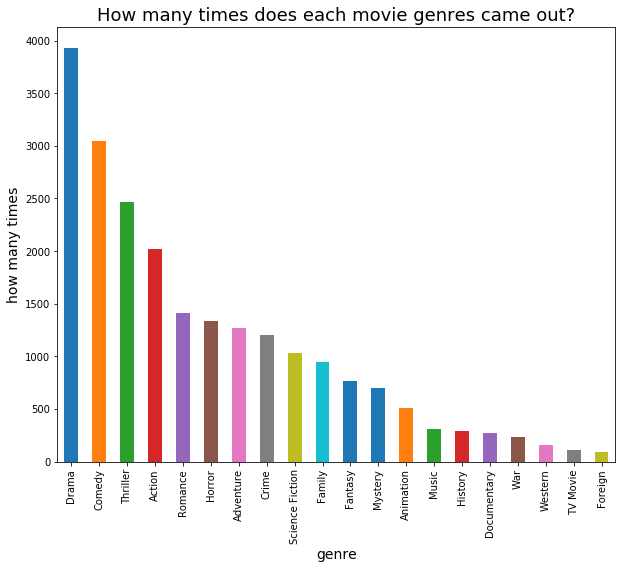

```python
q2_df.plot(kind='bar', figsize=(10, 8))
plt.title('How many times does each movie genres came out?', fontsize=18)
plt.xlabel('genre', fontsize=14)
plt.ylabel('how many times', fontsize=14);
```

`Drama` genre have camed out the most and `Foreigner` genre has the least.  
Personally this result came out special to me because I was assuming `Thriller` and `Action` will be the top

### Q3 - How much money cost to make each genres?

We are going to use `budget`, `genres` columns to analysis this.  
To make this available we have to make a new dataframe that will split the genres column's row to multi row.

```python
# dataframe, S., 2020. Split Cell Into Multiple Rows In Pandas Dataframe.
# [online] Stack Overflow.
# Available at: <https://stackoverflow.com/questions/50731229/split-cell-into-multiple-rows-in-pandas-dataframe>
from itertools import chain

# Get the lenghts information for each rows in genres
lens = df.genres.str.split('|').map(len)

# Create a new dataframe
q3_df = pd.DataFrame({'budget': np.repeat(df['budget'], lens),
                      'genres': list(chain.from_iterable(df.genres.str.split('|')))})
```

```python
# Check the value inside
q3_df.head(10)
```

|  | budget | genres |
| --- | --- | --- |
| 0 | 150000000 | Action |
| 0 | 150000000 | Adventure |
| 0 | 150000000 | Science Fiction |
| 0 | 150000000 | Thriller |
| 1 | 150000000 | Action |
| 1 | 150000000 | Adventure |
| 1 | 150000000 | Science Fiction |
| 1 | 150000000 | Thriller |
| 2 | 110000000 | Adventure |
| 2 | 110000000 | Science Fiction |

```python
# We can reset the index but not necessary
q3_df.reset_index(drop=True, inplace=True)
q3_df.head(5)
```

|  | budget | genres |
| --- | --- | --- |
| 0 | 150000000 | Action |
| 1 | 150000000 | Adventure |
| 2 | 150000000 | Science Fiction |
| 3 | 150000000 | Thriller |
| 4 | 150000000 | Action |

```python
# group by genres and calculate the total budget for each movie
q3_df = q3_df.groupby('genres').sum()
q3_df.sort_values(by='budget', axis=0, ascending=False, inplace=True, kind='quicksort')
q3_df
```

| genres | budget |
| --- | --- |
| Action | 64250155536 |
| Drama | 54445787998 |
| Adventure | 53860103867 |
| Comedy | 48425643983 |
| Thriller | 48218425116 |
| Science Fiction | 30437627021 |
| Fantasy | 28987541037 |
| Family | 27595744365 |
| Crime | 23139486703 |
| Romance | 20508891023 |
| Animation | 15694127130 |
| Mystery | 12697102251 |
| Horror | 9775499189 |
| History | 5991375813 |
| War | 5518695123 |
| Music | 3624110000 |
| Western | 3081727816 |
| Documentary | 256496312 |
| Foreign | 186076926 |
| TV Movie | 32700000 |

```python
# Get the total number of genre
color_lens = len(q3_df)

# Generate color depend on the order
colors = np.linspace(0, 1, color_lens)
```

```python
# Change the format to the [r, g, b, alpha=1]
colors_rgba = []

for c in colors:
    colors_rgba.append([c, c, 0.5, 1])
```

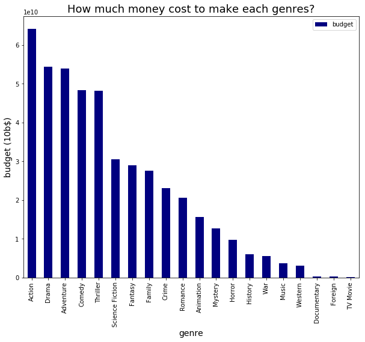

```python
# Need to find out how to plot the bar color all different using colors_rgba
# Currently applied for the first color
q3_df.plot(kind='bar', figsize=(10, 8), color=colors_rgba)
plt.title('How much money cost to make each genres?', fontsize=18)
plt.xlabel('genre', fontsize=14)
plt.ylabel('budget (10b\$)', fontsize=14)
plt.legend();
```

`Action` and the `Drama` genre spent the most money out of all genre and the `TV Movie` genre spent the least. But we have to consider that the budget spent at here might be expensive on `Action` because many people made action movie! So we can divide this by the number of genre made using the **how many?** information we made above **Q2**

```python
# q2_df was series so rebuild it as pandas dataframe
q2_df = pd.DataFrame({'genres': list(q2_df.index),
                      'how_many': q2_df})
q2_df.reset_index(drop=True, inplace=True)
```

```python
q2_df
```

|  | genres | how_many |
| --- | --- | --- |
| 0 | Drama | 3934 |
| 1 | Comedy | 3050 |
| 2 | Thriller | 2462 |
| 3 | Action | 2022 |
| 4 | Romance | 1415 |
| 5 | Horror | 1339 |
| 6 | Adventure | 1271 |
| 7 | Crime | 1200 |
| 8 | Science Fiction | 1028 |
| 9 | Family | 946 |
| 10 | Fantasy | 763 |
| 11 | Mystery | 703 |
| 12 | Animation | 512 |
| 13 | Music | 309 |
| 14 | History | 287 |
| 15 | Documentary | 270 |
| 16 | War | 235 |
| 17 | Western | 154 |
| 18 | TV Movie | 115 |
| 19 | Foreign | 90 |

Now we have the number of how many times the each genre have been filmed now let's divide it to budget. To do this first lets merge 2 dataframe `q2_df`, `q3_df`

```python
# Inner join 2 dataframe
df_combined = pd.merge(q2_df, q3_df, how='inner', left_on='genres', right_on='genres')
df_combined
```

|  | genres | how_many | budget |
| --- | --- | --- | --- |
| 0 | Drama | 3934 | 54445787998 |
| 1 | Comedy | 3050 | 48425643983 |
| 2 | Thriller | 2462 | 48218425116 |
| 3 | Action | 2022 | 64250155536 |
| 4 | Romance | 1415 | 20508891023 |
| 5 | Horror | 1339 | 9775499189 |
| 6 | Adventure | 1271 | 53860103867 |
| 7 | Crime | 1200 | 23139486703 |
| 8 | Science Fiction | 1028 | 30437627021 |
| 9 | Family | 946 | 27595744365 |
| 10 | Fantasy | 763 | 28987541037 |
| 11 | Mystery | 703 | 12697102251 |
| 12 | Animation | 512 | 15694127130 |
| 13 | Music | 309 | 3624110000 |
| 14 | History | 287 | 5991375813 |
| 15 | Documentary | 270 | 256496312 |
| 16 | War | 235 | 5518695123 |
| 17 | Western | 154 | 3081727816 |
| 18 | TV Movie | 115 | 32700000 |
| 19 | Foreign | 90 | 186076926 |

```python
df_combined.info()
```

```
<class 'pandas.core.frame.DataFrame'>
Int64Index: 20 entries, 0 to 19
Data columns (total 3 columns):
genres      20 non-null object
how_many    20 non-null int64
budget      20 non-null int64
dtypes: int64(2), object(1)
memory usage: 640.0+ bytes
```

Now let's create a new column that will store a average budget per movie

```python
df_combined['avg_budget_per_movie'] = df_combined.budget/df_combined.how_many
df_combined
```

|  | genres | how_many | budget | avg_budget_per_movie |
| --- | --- | --- | --- | --- |
| 0 | Drama | 3934 | 54445787998 | 1.383980e+07 |
| 1 | Comedy | 3050 | 48425643983 | 1.587726e+07 |
| 2 | Thriller | 2462 | 48218425116 | 1.958506e+07 |
| 3 | Action | 2022 | 64250155536 | 3.177555e+07 |
| 4 | Romance | 1415 | 20508891023 | 1.449392e+07 |
| 5 | Horror | 1339 | 9775499189 | 7.300597e+06 |
| 6 | Adventure | 1271 | 53860103867 | 4.237616e+07 |
| 7 | Crime | 1200 | 23139486703 | 1.928291e+07 |
| 8 | Science Fiction | 1028 | 30437627021 | 2.960859e+07 |
| 9 | Family | 946 | 27595744365 | 2.917098e+07 |
| 10 | Fantasy | 763 | 28987541037 | 3.799153e+07 |
| 11 | Mystery | 703 | 12697102251 | 1.806131e+07 |
| 12 | Animation | 512 | 15694127130 | 3.065259e+07 |
| 13 | Music | 309 | 3624110000 | 1.172851e+07 |
| 14 | History | 287 | 5991375813 | 2.087587e+07 |
| 15 | Documentary | 270 | 256496312 | 9.499863e+05 |
| 16 | War | 235 | 5518695123 | 2.348381e+07 |
| 17 | Western | 154 | 3081727816 | 2.001122e+07 |
| 18 | TV Movie | 115 | 32700000 | 2.843478e+05 |
| 19 | Foreign | 90 | 186076926 | 2.067521e+06 |

```python
# sort value
df_combined.sort_values(by='avg_budget_per_movie', axis=0, ascending=False, inplace=True, kind='quicksort')
```

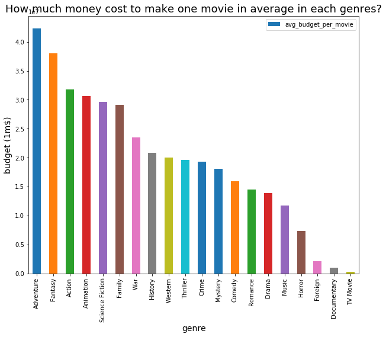

```python
df_combined.plot(x='genres', y='avg_budget_per_movie', figsize=(10, 8), kind='bar')
plt.title('How much money cost to make one movie in average in each genres?', fontsize=18)
plt.xlabel('genre', fontsize=14)
plt.ylabel('budget (1m\$)', fontsize=14)
plt.legend();
```

Now we can see much clear that which genre cost most money! `Drama` spent a lot of money but the actual cost is low as we can see at the graph! `Adventure` is the most expensive genre and `TV Movie` spend the least money!

### Q4 - Which actor has the most popularity?

```python
df.head()
```

|  | popularity | budget | revenue | title | cast | director | keywords | runtime | genres | production_companies | month | vote_count | vote_average | year |
| --- | --- | --- | --- | --- | --- | --- | --- | --- | --- | --- | --- | --- | --- | --- |
| 0 | 32.985763 | 150000000 | 1513528810 | Jurassic World | Chris Pratt\|Bryce Dallas Howard\|Irrfan Khan\|Vi... | Colin Trevorrow | monster\|dna\|tyrannosaurus rex\|velociraptor\|island | 124 | Action\|Adventure\|Science Fiction\|Thriller | Universal Studios\|Amblin Entertainment\|Legenda... | 6 | 5562 | 6.5 | 2015 |
| 1 | 28.419936 | 150000000 | 378436354 | Mad Max: Fury Road | Tom Hardy\|Charlize Theron\|Hugh Keays-Byrne\|Nic... | George Miller | future\|chase\|post-apocalyptic\|dystopia\|australia | 120 | Action\|Adventure\|Science Fiction\|Thriller | Village Roadshow Pictures\|Kennedy Miller Produ... | 5 | 6185 | 7.1 | 2015 |
| 2 | 13.112507 | 110000000 | 295238201 | Insurgent | Shailene Woodley\|Theo James\|Kate Winslet\|Ansel... | Robert Schwentke | based on novel\|revolution\|dystopia\|sequel\|dyst... | 119 | Adventure\|Science Fiction\|Thriller | Summit Entertainment\|Mandeville Films\|Red Wago... | 3 | 2480 | 6.3 | 2015 |
| 3 | 11.173104 | 200000000 | 2068178225 | Star Wars: The Force Awakens | Harrison Ford\|Mark Hamill\|Carrie Fisher\|Adam D... | J.J. Abrams | android\|spaceship\|jedi\|space opera\|3d | 136 | Action\|Adventure\|Science Fiction\|Fantasy | Lucasfilm\|Truenorth Productions\|Bad Robot | 12 | 5292 | 7.5 | 2015 |
| 4 | 9.335014 | 190000000 | 1506249360 | Furious 7 | Vin Diesel\|Paul Walker\|Jason Statham\|Michelle ... | James Wan | car race\|speed\|revenge\|suspense\|car | 137 | Action\|Crime\|Thriller | Universal Pictures\|Original Film\|Media Rights ... | 4 | 2947 | 7.3 | 2015 |

```python
from itertools import chain

# calculate the length
lens = df['cast'].str.split('|').map(len)

# Create a new dataframe
q4_df = pd.DataFrame({'popularity': np.repeat(df['popularity'], lens),
                      'actor': list(chain.from_iterable(df.cast.str.split('|')))})
```

```python
q4_df.head()
```

|  | popularity | actor |
| --- | --- | --- |
| 0 | 32.985763 | Chris Pratt |
| 0 | 32.985763 | Bryce Dallas Howard |
| 0 | 32.985763 | Irrfan Khan |
| 0 | 32.985763 | Vincent D'Onofrio |
| 0 | 32.985763 | Nick Robinson |

```python
# group by actor and calculate the total popularity for each actor
q4_df = q4_df.groupby('actor').sum()
q4_df.sort_values(by='popularity', axis=0, ascending=False, inplace=True, kind='quicksort')
q4_df.head(5)
```

| actor | popularity |
| --- | --- |
| Samuel L. Jackson | 91.868694 |
| Michael Caine | 82.634623 |
| Harrison Ford | 79.035897 |
| Bruce Willis | 77.058590 |
| Robert De Niro | 76.546720 |

```python
# check the data shape
q4_df.shape
```

```
(15332, 1)
```

There are total 15332 actors existing and we now let's see the statistics of the popularity. 75% of people are below 1.411 and above has much more score. As we can see it is skewed to right.

```python
q4_df.describe()
```

|  | popularity |
| --- | --- |
| count | 15332.000000 |
| mean | 2.085233 |
| std | 5.448609 |
| min | 0.000620 |
| 25% | 0.244550 |
| 50% | 0.513739 |
| 75% | 1.411429 |
| max | 91.868694 |

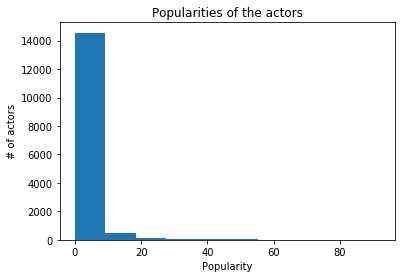

```python
# reversed order
q4_df.popularity[::-1].plot(kind='hist')
plt.title('Popularities of the actors')
plt.xlabel('Popularity')
plt.ylabel('# of actors');
```

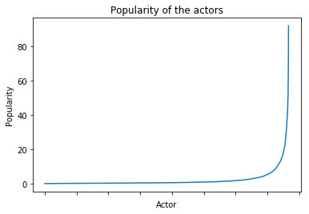

```python
# reversed order
q4_df.popularity[::-1].plot(kind='line')
plt.title('Popularity of the actors')
plt.xlabel('Actor')
plt.ylabel('Popularity');
```

```python
# max popularity actor
q4_df.query('popularity == {}'.format(q4_df.popularity.max()))
```

| actor | popularity |
| --- | --- |
| Samuel L. Jackson | 91.868694 |

```python
# min popularity actor
q4_df.query('popularity == {}'.format(q4_df.popularity.min()))
```

| actor | popularity |
| --- | --- |
| Molly Tarlov | 0.00062 |
| Andrea Bowen | 0.00062 |
| Michael J. Willett | 0.00062 |

`Samuel L. Jackson` is the most popular actor and `Molly Tarlov, Andrea Bowen, Michael J. Willett` is the least popular actors

### Q5 - Which keywords appear the most?

```python
# Add all the keywords in one variable
keywords = df.keywords.str.cat(sep='|')

# Split it and make it to a long list of keywords dataframe
q5_df = pd.Series(keywords.split('|'))

# store again by counting each values
q5_df = q5_df.value_counts()
```

```python
# Cut to 10 because there are 7,578 keywords and its too much
top_10 = q5_df[:10]
top_10
```

```
independent film    339
woman director      335
based on novel      271
sex                 263
sport               200
murder              194
biography           160
new york            159
nudity              153
suspense            152
dtype: int64
```

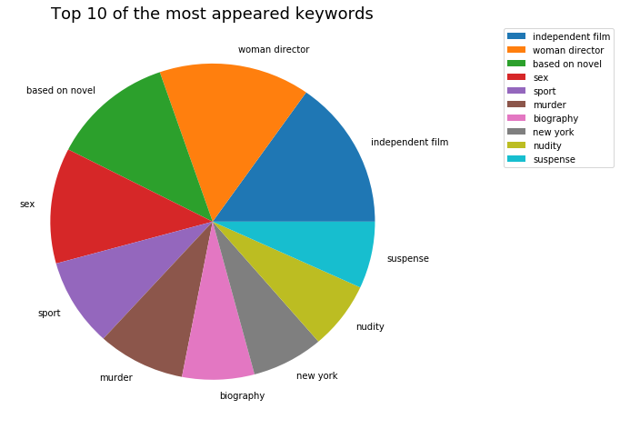

```python
top_10.plot(kind='pie', figsize=(8,8))
plt.title("Top 10 of the most appeared keywords", fontsize=18)
plt.xlabel('')
plt.ylabel('')
plt.legend(bbox_to_anchor=(1.5, 1), loc="best");
```

`Independent film` was the keyword that mostly appeared. Interesting keyword was `woman director` because the word **woman** was emphasized and it might mean the movie made by woman is special and unique. Keywords like `sex, sport, murder, nudity, suspense` is popular keywords so not surprising to see at here but `new york` keyword might seems special and it stimulates curiousity why it came out so often.

### Q6 - What movie has the most expensive cost per second?

```python
# Make a new dataframe for question 6
q6_df = df[['title', 'budget', 'runtime']].copy()
q6_df.head(1)
```

|  | title | budget | runtime |
| --- | --- | --- | --- |
| 0 | Jurassic World | 150000000 | 124 |

```python
q6_df['budget_per_second'] = q6_df['budget']/(q6_df['runtime']*60)
q6_df.head(1)
```

|  | title | budget | runtime | budget_per_second |
| --- | --- | --- | --- | --- |
| 0 | Jurassic World | 150000000 | 124 | 20161.290323 |

```python
# sort by budget per second
q6_df.sort_values(by='budget_per_second', axis=0, ascending=False, inplace=True, kind='quicksort')

# Remove the movie which has 0 runtime
q6_df = q6_df.query('runtime != 0')

# Reset the index
q6_df.reset_index(drop=True, inplace=True)

q6_df.head(5)
```

|  | title | budget | runtime | budget_per_second |
| --- | --- | --- | --- | --- |
| 0 | The Warrior's Way | 425000000 | 100 | 70833.333333 |
| 1 | Pirates of the Caribbean: On Stranger Tides | 380000000 | 136 | 46568.627451 |
| 2 | Tangled | 260000000 | 100 | 43333.333333 |
| 3 | Shrek the Halls | 60000000 | 28 | 35714.285714 |
| 4 | Men in Black 3 | 225000000 | 106 | 35377.358491 |

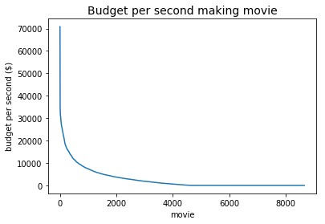

```python
q6_df['budget_per_second'].plot(kind='line')
plt.title('Budget per second making movie', fontsize=14)
plt.xlabel('movie')
plt.ylabel('budget per second (\$)');
```

```python
# The most expensive cost per second
q6_df.query('budget_per_second == budget_per_second.max()')
```

|  | title | budget | runtime | budget_per_second |
| --- | --- | --- | --- | --- |
| 0 | The Warrior's Way | 425000000 | 100 | 70833.333333 |

```python
# The most cheap cost per second
q6_df.query('budget_per_second == budget_per_second.min()')
```

|  | title | budget | runtime | budget_per_second |
| --- | --- | --- | --- | --- |
| 4725 | In Her Shoes | 0 | 130 | 0.0 |
| 4726 | To Live and Die in L.A. | 0 | 116 | 0.0 |
| 4727 | The Falcon and the Snowman | 0 | 132 | 0.0 |
| 4728 | American Flyers | 0 | 113 | 0.0 |
| 4729 | House of Versace | 0 | 85 | 0.0 |
| 4730 | Anne of Green Gables | 0 | 199 | 0.0 |
| 4731 | My Science Project | 0 | 94 | 0.0 |
| 4732 | Toy Story of Terror! | 0 | 22 | 0.0 |
| 4733 | Howling II: Stirba - Werewolf Bitch | 0 | 91 | 0.0 |
| 4734 | White Nights | 0 | 136 | 0.0 |
| 4735 | Just Friends | 0 | 96 | 0.0 |
| 4736 | Transylvania 6-5000 | 0 | 93 | 0.0 |
| 4737 | Secret Admirer | 0 | 90 | 0.0 |
| 4738 | The Journey of Natty Gann | 0 | 101 | 0.0 |
| 4739 | Mischief | 0 | 93 | 0.0 |
| 4740 | Volunteers | 0 | 107 | 0.0 |
| 4741 | Little Manhattan | 0 | 84 | 0.0 |
| 4742 | The Care Bears Movie | 0 | 77 | 0.0 |
| 4743 | Summer Rental | 0 | 87 | 0.0 |
| 4744 | Fandango | 0 | 91 | 0.0 |
| 4745 | St. Elmo's Fire | 0 | 110 | 0.0 |
| 4746 | Silver Bullet | 0 | 95 | 0.0 |
| 4747 | Kiss of the Spider Woman | 0 | 120 | 0.0 |
| 4748 | Teen Wolf | 0 | 91 | 0.0 |
| 4749 | Beyonce: Life Is But A Dream | 0 | 88 | 0.0 |
| 4750 | A Viking Saga: The Darkest Day | 0 | 82 | 0.0 |
| 4751 | I Know That Voice | 0 | 90 | 0.0 |
| 4752 | TINY: A Story About Living Small | 0 | 62 | 0.0 |
| 4753 | Remo Williams: The Adventure Begins... | 0 | 121 | 0.0 |
| 4754 | Vision Quest | 0 | 105 | 0.0 |
| ... | ... | ... | ... | ... |
| 8629 | Gray Lady Down | 0 | 111 | 0.0 |
| 8630 | Someone's Watching Me! | 0 | 97 | 0.0 |
| 8631 | Carry On Screaming! | 0 | 87 | 0.0 |
| 8632 | Solace | 0 | 101 | 0.0 |
| 8633 | Grand Prix | 0 | 176 | 0.0 |
| 8634 | Gambit | 0 | 109 | 0.0 |
| 8635 | Harper | 0 | 121 | 0.0 |
| 8636 | Born Free | 0 | 95 | 0.0 |
| 8637 | A Big Hand for the Little Lady | 0 | 95 | 0.0 |
| 8638 | The Chase | 0 | 135 | 0.0 |
| 8639 | Mr. Holmes | 0 | 103 | 0.0 |
| 8640 | The Ugly Dachshund | 0 | 93 | 0.0 |
| 8641 | Nevada Smith | 0 | 128 | 0.0 |
| 8642 | The Russians Are Coming, The Russians Are Coming | 0 | 126 | 0.0 |
| 8643 | Seconds | 0 | 100 | 0.0 |
| 8644 | The Endless Summer | 0 | 95 | 0.0 |
| 8645 | The Manitou | 0 | 104 | 0.0 |
| 8646 | Beregis Avtomobilya | 0 | 94 | 0.0 |
| 8647 | Everly | 0 | 90 | 0.0 |
| 8648 | What's Up, Tiger Lily? | 0 | 80 | 0.0 |
| 8649 | Mythica: The Darkspore | 0 | 108 | 0.0 |
| 8650 | How to Steal a Million | 0 | 123 | 0.0 |
| 8651 | Mistress America | 0 | 84 | 0.0 |
| 8652 | Me and Earl and the Dying Girl | 0 | 105 | 0.0 |
| 8653 | The Fury | 0 | 118 | 0.0 |
| 8654 | Slow West | 0 | 84 | 0.0 |
| 8655 | Eyes of Laura Mars | 0 | 104 | 0.0 |
| 8656 | The Boys from Brazil | 0 | 125 | 0.0 |
| 8657 | The Medusa Touch | 0 | 105 | 0.0 |
| 8658 | Hateship Loveship | 0 | 103 | 0.0 |

3934 rows × 4 columns

The most expensive movie is `The warrior's Way` and there are 3934 movies that doesn't cost any budget. But personally this data of budget might be incorrect. At least there should be some budget cost. So it might be good to ignore the movie that has 0\$ budget

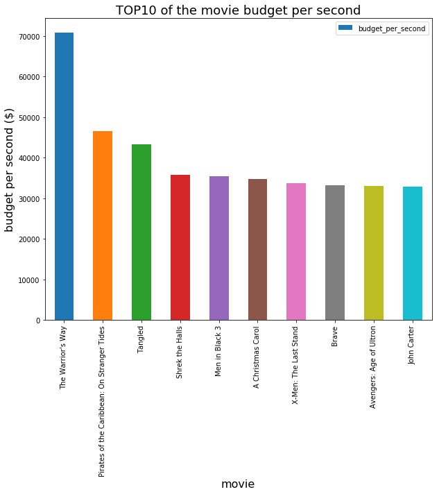

```python
q6_df[['title', 'budget_per_second']].iloc[:10].plot(x='title', y='budget_per_second', kind='bar', figsize=(10, 8))
plt.title('TOP10 of the movie budget per second', fontsize=18)
plt.xlabel('movie', fontsize=16)
plt.ylabel('budget per second (\$)',fontsize=16);
```

To make a 1 second of movie scene it cost more than **\$10000**! Its very expensive!!! 😃  
Interestingly `The Warrior's Way` was the movie that has the least profit among all the movies.

### Q7 - What seem to be the success point of the movie?

The success point at here will be the profit

```python
# We are going to use Q1 dataframe because it already calculated profit
q7_df = q1_df.copy()

# make a function to handle relation between object data type and profit
def profit_relation(df, c):
    """
    args
        df - dataframe
        c - column name
    return
        new_df - new generated dataframe
    """
    lens = df[c].str.split('|').map(len)

    # Create a new dataframe
    new_df = pd.DataFrame({'profit': np.repeat(df['profit'], lens),
                           c: list(chain.from_iterable(df[c].str.split('|')))})

    new_df.sort_values(by='profit', axis=0, ascending=False, inplace=True, kind='quicksort')

    # Reset the index
    new_df.reset_index(drop=True, inplace=True)
    return new_df
```

The properties we can check using the `profit relation` function

1. cast
2. director
3. keywords
4. genres
5. production companies

```python
# cast
cast_df = profit_relation(q7_df, 'cast')

# director
director_df = profit_relation(q7_df, 'director')

# keywords
keywords_df = profit_relation(q7_df, 'keywords')

# genres
genres_df = profit_relation(q7_df, 'genres')

# production companies
production_companies_df = profit_relation(q7_df, 'production_companies')
```

```python
profit_df = pd.concat([cast_df, director_df, keywords_df, genres_df, production_companies_df], axis=1)
profit_df.head(10)
```

|  | profit | cast | profit | director | profit | keywords | profit | genres | profit | production_companies |
| --- | --- | --- | --- | --- | --- | --- | --- | --- | --- | --- |
| 0 | 2544505847 | Sam Worthington | 2.544506e+09 | James Cameron | 2.544506e+09 | space war | 2.544506e+09 | Science Fiction | 2.544506e+09 | Ingenious Film Partners |
| 1 | 2544505847 | Zoe Saldana | 1.868178e+09 | J.J. Abrams | 2.544506e+09 | culture clash | 2.544506e+09 | Adventure | 2.544506e+09 | Twentieth Century Fox Film Corporation |
| 2 | 2544505847 | Sigourney Weaver | 1.645034e+09 | James Cameron | 2.544506e+09 | future | 2.544506e+09 | Action | 2.544506e+09 | Dune Entertainment |
| 3 | 2544505847 | Stephen Lang | 1.363529e+09 | Colin Trevorrow | 2.544506e+09 | space colony | 2.544506e+09 | Fantasy | 2.544506e+09 | Lightstorm Entertainment |
| 4 | 2544505847 | Michelle Rodriguez | 1.316249e+09 | James Wan | 2.544506e+09 | society | 1.868178e+09 | Adventure | 1.868178e+09 | Lucasfilm |
| 5 | 1868178225 | Harrison Ford | 1.299558e+09 | Joss Whedon | 1.868178e+09 | android | 1.868178e+09 | Fantasy | 1.868178e+09 | Bad Robot |
| 6 | 1868178225 | Daisy Ridley | 1.202818e+09 | David Yates | 1.868178e+09 | 3d | 1.868178e+09 | Science Fiction | 1.868178e+09 | Truenorth Productions |
| 7 | 1868178225 | Adam Driver | 1.125036e+09 | Joss Whedon | 1.868178e+09 | space opera | 1.868178e+09 | Action | 1.645034e+09 | Lightstorm Entertainment |
| 8 | 1868178225 | Carrie Fisher | 1.124219e+09 | Jennifer Lee | 1.868178e+09 | jedi | 1.645034e+09 | Drama | 1.645034e+09 | Paramount Pictures |
| 9 | 1868178225 | Mark Hamill | 1.124219e+09 | Chris Buck | 1.868178e+09 | spaceship | 1.645034e+09 | Romance | 1.645034e+09 | Twentieth Century Fox Film Corporation |

We can think that this cast, directors etc might be the reason of the success.

```python
q7_df.query('profit == 2544505847')
```

|  | popularity | budget | revenue | title | cast | director | keywords | runtime | genres | production_companies | month | vote_count | vote_average | year | profit |
| --- | --- | --- | --- | --- | --- | --- | --- | --- | --- | --- | --- | --- | --- | --- | --- |
| 1014 | 9.432768 | 237000000 | 2781505847 | Avatar | Sam Worthington\|Zoe Saldana\|Sigourney Weaver\|S... | James Cameron | culture clash\|future\|space war\|space colony\|so... | 162 | Action\|Adventure\|Fantasy\|Science Fiction | Ingenious Film Partners\|Twentieth Century Fox ... | 12 | 8458 | 7.1 | 2009 | 2544505847 |

```python
q7_df.query('profit == 1868178225')
```

|  | popularity | budget | revenue | title | cast | director | keywords | runtime | genres | production_companies | month | vote_count | vote_average | year | profit |
| --- | --- | --- | --- | --- | --- | --- | --- | --- | --- | --- | --- | --- | --- | --- | --- |
| 3 | 11.173104 | 200000000 | 2068178225 | Star Wars: The Force Awakens | Harrison Ford\|Mark Hamill\|Carrie Fisher\|Adam D... | J.J. Abrams | android\|spaceship\|jedi\|space opera\|3d | 136 | Action\|Adventure\|Science Fiction\|Fantasy | Lucasfilm\|Truenorth Productions\|Bad Robot | 12 | 5292 | 7.5 | 2015 | 1868178225 |

But we cannot trust because the sample is too small. The profitable cast, directors etc are not chosen of the result of several samples. It was chosen only by one movie. So we cannot say that specific cast, directors etc are the reason of the success. It is interesting that the property values used in `Avatar` and `Star Wars: The Force Awakens` might used in other movies too but only appeared in those 2 movies

**Now let's check the correlation between numeric values**

```python
num_df = q7_df[['popularity', 'runtime', 'vote_count', 'vote_average', 'month', 'year', 'profit']]
```

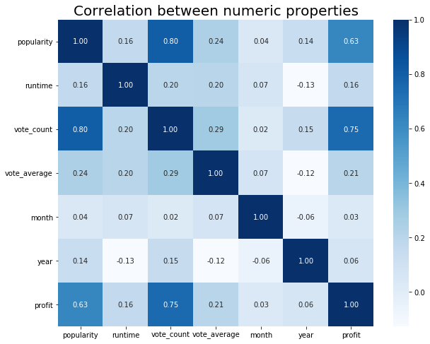

```python
plt.figure(figsize=(10, 8))
plt.title('Correlation between numeric properties', fontsize=20)
sns.heatmap(data=num_df.corr(),
            annot=True,
            fmt='.2f',
            cmap='Blues');
```

We can check `profit` has correlation with `popularity` and `vote count`

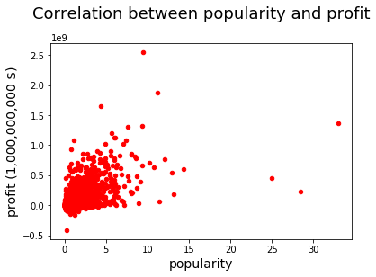

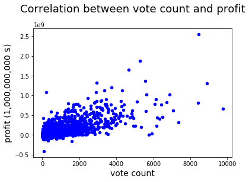

```python
# correlation between popularity and profit
q7_df.plot(x='popularity', y='profit', kind='scatter', color='red')
plt.title('Correlation between popularity and profit',
          fontsize=18,
          position=(0.5, 1.1))
plt.xlabel('popularity', fontsize=14)
plt.ylabel('profit (1,000,000,000 \$)', fontsize=14)

# correlation between vote count and profit
q7_df.plot(x='vote_count', y='profit', kind='scatter', color='blue')
plt.title('Correlation between vote count and profit',
          fontsize=18,
          position=(0.5, 1.1))
plt.xlabel('vote count', fontsize=14)
plt.ylabel('profit (1,000,000,000 \$)', fontsize=14);
```

In this questions there is no clear answer. We can only observe the result itself.

## Conclusions

We investigated the dataset and answered 7 questions that could be derived from the dataset.

**Q1 - What is the most and least profitable movie?**  
**Q2 - How many times does each movie genre have came out?**  
**Q3 - How much money cost to make each genres?**  
**Q4 - Which actor has the most popularity?**  
**Q5 - Which keywords appear the most?**  
**Q6 - What movie has the most expensive cost per second?**  
**Q7 - What seem to be the success point of the movie?**

- `The Warrior's Way` has the least profit - 413,912,431 \\$ `Avatar` has the most profit + 2,544,505,847 \\$
- `Drama` genre have camed out the most and `Foreigner` genre has the least.
- `Adventure` genre spent to most money to make one movie and `TV Movie` spend the least money!
- `Samuel L. Jackson` is the most popular actor and `Molly Tarlov, Andrea Bowen, Michael J. Willett` is the least popular actors
- `Independent film` was the keyword that mostly appeared.
- `The warrior's Way` has spent the most money to make one second of movie in average.
- There is no clear key properties that shows the relation between profit. It needs more sample. Just for checking correlation between numeric properties `popularity` and `vote count` has correlation between profit.

We go through the dataset and get some insights about the movie industry. Further we could explore more on month, year but here we stop even we have much more to explore! The sample of movie set is small less than 10,000 so its hard to make some clear conclusions but we can get some glimpse about what is going around 😎

## Submitting your Project

> Before you submit your project, you need to create a .html or .pdf version of this notebook in the workspace here. To do that, run the code cell below. If it worked correctly, you should get a return code of 0, and you should see the generated .html file in the workspace directory (click on the orange Jupyter icon in the upper left).

> Alternatively, you can download this report as .html via the **File** > **Download as** submenu, and then manually upload it into the workspace directory by clicking on the orange Jupyter icon in the upper left, then using the Upload button.

> Once you've done this, you can submit your project by clicking on the "Submit Project" button in the lower right here. This will create and submit a zip file with this .ipynb doc and the .html or .pdf version you created. Congratulations!

```python
from subprocess import call
call(['python', '-m', 'nbconvert', 'Investigate_a_Dataset.ipynb'])
```